# PSTAT 131 Homework 2

Sunrise Gao

10/14/2022

## Linear Regression

For this lab, we will be working with a data set from the UCI (University of California, Irvine) Machine Learning repository ([see website here](http://archive.ics.uci.edu/ml/datasets/Abalone)). The full data set consists of $4,177$ observations of abalone in Tasmania. (Fun fact: Tasmania supplies about $25\%$ of the yearly world abalone harvest.)

The age of an abalone is typically determined by cutting the shell open and counting the number of rings with a microscope. The purpose of this data set is to determine whether abalone age (**number of rings + 1.5**) can be accurately predicted using other, easier-to-obtain information about the abalone.

The full abalone data set is located in the `\data` subdirectory. Read it into *R* using `read_csv()`. Take a moment to read through the codebook (`abalone_codebook.txt`) and familiarize yourself with the variable definitions.

Make sure you load the `tidyverse` and `tidymodels`!

```r
library(ggplot2)
library(tidyverse)
library(tidymodels)
library(corrplot)
library(ggthemes)
tidymodels_prefer()
tidymodels_packages()
```

```
##  [1] "broom"        "cli"          "conflicted"   "dials"        "dplyr"
##  [6] "ggplot2"      "hardhat"      "infer"        "modeldata"    "parsnip"
## [11] "purrr"        "recipes"      "rlang"        "rsample"      "rstudioapi"
## [16] "tibble"       "tidyr"        "tune"         "workflows"    "workflowsets"
## [21] "yardstick"    "tidymodels"
```

```r
abalone <- read.csv("abalone.csv")
head(abalone)
```

```
##   type longest_shell diameter height whole_weight shucked_weight viscera_weight
## 1    M         0.455    0.365  0.095       0.5140         0.2245         0.1010
## 2    M         0.350    0.265  0.090       0.2255         0.0995         0.0485
## 3    F         0.530    0.420  0.135       0.6770         0.2565         0.1415
## 4    M         0.440    0.365  0.125       0.5160         0.2155         0.1140
## 5    I         0.330    0.255  0.080       0.2050         0.0895         0.0395
## 6    I         0.425    0.300  0.095       0.3515         0.1410         0.0775
##   shell_weight rings
## 1        0.150    15
## 2        0.070     7
## 3        0.210     9
## 4        0.155    10
## 5        0.055     7
## 6        0.120     8
```

### Question 1

Your goal is to predict abalone age, which is calculated as the number of rings plus 1.5. Notice there currently is no `age` variable in the data set. Add `age` to the data set.

Assess and describe the distribution of `age`.

```r
abalone_new <- abalone %>%
  mutate(age = rings + 1.5)

head(abalone_new)
```

```
##   type longest_shell diameter height whole_weight shucked_weight viscera_weight
## 1    M         0.455    0.365  0.095       0.5140         0.2245         0.1010
## 2    M         0.350    0.265  0.090       0.2255         0.0995         0.0485
## 3    F         0.530    0.420  0.135       0.6770         0.2565         0.1415
## 4    M         0.440    0.365  0.125       0.5160         0.2155         0.1140
## 5    I         0.330    0.255  0.080       0.2050         0.0895         0.0395
## 6    I         0.425    0.300  0.095       0.3515         0.1410         0.0775
##   shell_weight rings  age
## 1        0.150    15 16.5
## 2        0.070     7  8.5
## 3        0.210     9 10.5
## 4        0.155    10 11.5
## 5        0.055     7  8.5
## 6        0.120     8  9.5
```

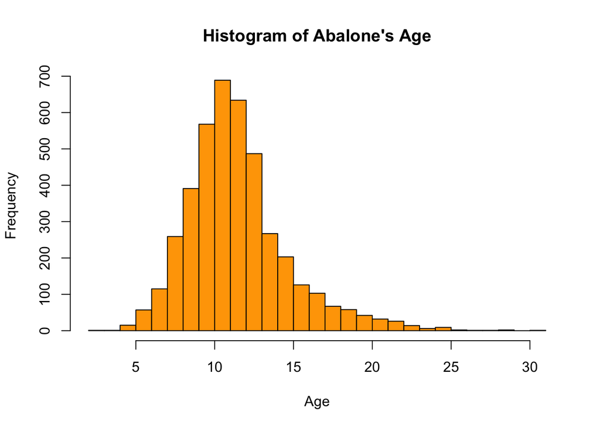

```r
hist(abalone_new$age, xlab = "Age",breaks =30, main = "Histogram of Abalone's Age", col = 'orange')
```

### Question 2

Split the abalone data into a training set and a testing set. Use stratified sampling. You should decide on appropriate percentages for splitting the data.

*Remember that you’ll need to set a seed at the beginning of the document to reproduce your results.*

```r
set.seed(2000)

abalone_split <- initial_split(abalone_new, prop = 0.80, strata = age)
abalone_train <- training(abalone_split)
abalone_test <- testing(abalone_split)

head(abalone_train)
```

```
##    type longest_shell diameter height whole_weight shucked_weight
## 2     M         0.350    0.265  0.090       0.2255         0.0995
## 5     I         0.330    0.255  0.080       0.2050         0.0895
## 36    M         0.465    0.355  0.105       0.4795         0.2270
## 38    F         0.450    0.355  0.105       0.5225         0.2370
## 43    I         0.240    0.175  0.045       0.0700         0.0315
## 45    I         0.210    0.150  0.050       0.0420         0.0175
##    viscera_weight shell_weight rings age
## 2          0.0485        0.070     7 8.5
## 5          0.0395        0.055     7 8.5
## 36         0.1240        0.125     8 9.5
## 38         0.1165        0.145     8 9.5
## 43         0.0235        0.020     5 6.5
## 45         0.0125        0.015     4 5.5
```

```r
head(abalone_test)
```

```
##    type longest_shell diameter height whole_weight shucked_weight
## 6     I         0.425    0.300  0.095       0.3515         0.1410
## 11    F         0.525    0.380  0.140       0.6065         0.1940
## 17    I         0.355    0.280  0.085       0.2905         0.0950
## 19    M         0.365    0.295  0.080       0.2555         0.0970
## 21    M         0.355    0.280  0.095       0.2455         0.0955
## 24    F         0.550    0.415  0.135       0.7635         0.3180
##    viscera_weight shell_weight rings  age
## 6          0.0775        0.120     8  9.5
## 11         0.1475        0.210    14 15.5
## 17         0.0395        0.115     7  8.5
## 19         0.0430        0.100     7  8.5
## 21         0.0620        0.075    11 12.5
## 24         0.2100        0.200     9 10.5
```

### Question 3

Using the **training** data, create a recipe predicting the outcome variable, `age`, with all other predictor variables. Note that you should not include `rings` to predict `age`. Explain why you shouldn’t use `rings` to predict `age`.

Steps for your recipe:

1. dummy code any categorical predictors
2. create interactions between
   - `type` and `shucked_weight`,
   - `longest_shell` and `diameter`,
   - `shucked_weight` and `shell_weight`
3. center all predictors, and
4. scale all predictors.

You’ll need to investigate the `tidymodels` documentation to find the appropriate step functions to use.

```r
abalone_recipe <- abalone_train %>%
  recipe(age ~ type +longest_shell + diameter + height +
           whole_weight + shucked_weight + viscera_weight +
           shell_weight) %>%
  step_dummy(all_nominal_predictors())  %>%
  step_interact(terms = ~ starts_with("type"):shucked_weight+
                  longest_shell:diameter+
                  shucked_weight:shell_weight) %>%
  step_center(all_predictors()) %>%
  step_scale(all_predictors())
```

### Question 4

Create and store a linear regression object using the `"lm"` engine.

```r
lm_model <- linear_reg() %>%
  set_engine("lm")
```

### Question 5

Now:

1. set up an empty workflow,
2. add the model you created in Question 4, and
3. add the recipe that you created in Question 3.

```r
lm_wflow <- workflow() %>%
  add_model(lm_model) %>%
  add_recipe(abalone_recipe)
```

### Question 6

Use your `fit()` object to predict the age of a hypothetical female abalone with longest_shell = 0.50, diameter = 0.10, height = 0.30, whole_weight = 4, shucked_weight = 1, viscera_weight = 2, shell_weight = 1.

```r
#fitting the model
lm_fit <- fit(lm_wflow, abalone_train)
```

```r
#predicting
abalone_hypo <- data.frame(type="F",longest_shell = 0.50,
                           diameter = 0.10,
                           height = 0.30,
                           whole_weight = 4,
                           shucked_weight = 1,
                           viscera_weight = 2,
                           shell_weight = 1)
predict(lm_fit,new_data = abalone_hypo)
```

```
## # A tibble: 1 × 1
##   .pred
##   <dbl>
## 1  24.8
```

### Question 7

Now you want to assess your model’s performance. To do this, use the `yardstick` package:

1. Create a metric set that includes *R<sup>2</sup>*, RMSE (root mean squared error), and MAE (mean absolute error).

```r
abalone_metrics <- metric_set(rsq, rmse, mae)
```

2. Use `predict()` and `bind_cols()` to create a tibble of your model’s predicted values from the **training data** along with the actual observed ages (these are needed to assess your model’s performance).

```r
abalone_train_res <- predict(lm_fit, new_data = abalone_train %>% select(-age))


abalone_train_res <- bind_cols(abalone_train_res, abalone_train %>% select(age))
abalone_train_res %>%
  head()
```

```
## # A tibble: 6 × 2
##   .pred   age
##   <dbl> <dbl>
## 1  9.48   8.5
## 2  8.10   8.5
## 3 10.1    9.5
## 4 11.0    9.5
## 5  6.30   6.5
## 6  5.94   5.5
```

3. Finally, apply your metric set to the tibble, report the results, and interpret the *R<sup>2</sup>* value.

```r
abalone_metrics(abalone_train_res, truth = age, estimate = .pred)
```

```
## # A tibble: 3 × 3
##   .metric .estimator .estimate
##   <chr>   <chr>          <dbl>
## 1 rsq     standard       0.559
## 2 rmse    standard       2.13
## 3 mae     standard       1.53
```

*The R^2 represents how well the regression model fits the observed data. As the we getting rsq about 0.56, the model is not fitting the observed data well.*  
*The root mean squared error is the standard deviation of the residuals (prediction errors), As we are predicting the age of abalone, about 2.13 of rmse is a bit to big as a prediction error.*  
*mae: The mean absolute error indicates that the magnitude of difference between the prediction of an observation and the true value of that observation is about 1.53.*